# Risk Factor Analysis

## Outcome Variable

**Outcome Variable:** whz

## Predictor Variables

**Intervention Variable:** birthlen

**Adjustment Set:**

- arm
- sex
- W_mage
- meducyrs
- feducyrs
- vagbrth
- single
- brthmon
- W_parity
- delta_W_mage
- delta_meducyrs
- delta_feducyrs
- delta_vagbrth
- delta_single
- delta_brthmon
- delta_W_parity

## Stratifying Variables

The analysis was stratified on these variable(s):

- agecat
- studyid
- country

## Data Summary

| agecat | studyid | country | birthlen | n_cell | n |
| --- | --- | --- | --- | --- | --- |
| Birth | CMC-V-BCS-2002 | INDIA | >=50 cm | 13 | 86 |
| Birth | CMC-V-BCS-2002 | INDIA | <48 cm | 33 | 86 |
| Birth | CMC-V-BCS-2002 | INDIA | [48-50) cm | 40 | 86 |
| Birth | CMIN | BANGLADESH | >=50 cm | 2 | 19 |
| Birth | CMIN | BANGLADESH | <48 cm | 9 | 19 |
| Birth | CMIN | BANGLADESH | [48-50) cm | 8 | 19 |
| Birth | COHORTS | GUATEMALA | >=50 cm | 396 | 756 |
| Birth | COHORTS | GUATEMALA | <48 cm | 132 | 756 |
| Birth | COHORTS | GUATEMALA | [48-50) cm | 228 | 756 |
| Birth | COHORTS | INDIA | >=50 cm | 1404 | 6193 |
| Birth | COHORTS | INDIA | <48 cm | 2354 | 6193 |
| Birth | COHORTS | INDIA | [48-50) cm | 2435 | 6193 |
| Birth | COHORTS | PHILIPPINES | >=50 cm | 1110 | 2899 |
| Birth | COHORTS | PHILIPPINES | <48 cm | 651 | 2899 |
| Birth | COHORTS | PHILIPPINES | [48-50) cm | 1138 | 2899 |
| Birth | CONTENT | PERU | >=50 cm | 1 | 2 |
| Birth | CONTENT | PERU | <48 cm | 1 | 2 |
| Birth | CONTENT | PERU | [48-50) cm | 0 | 2 |
| Birth | EE | PAKISTAN | >=50 cm | 21 | 177 |
| Birth | EE | PAKISTAN | <48 cm | 102 | 177 |
| Birth | EE | PAKISTAN | [48-50) cm | 54 | 177 |
| Birth | GMS-Nepal | NEPAL | >=50 cm | 114 | 641 |
| Birth | GMS-Nepal | NEPAL | <48 cm | 319 | 641 |
| Birth | GMS-Nepal | NEPAL | [48-50) cm | 208 | 641 |
| Birth | IRC | INDIA | >=50 cm | 120 | 343 |
| Birth | IRC | INDIA | <48 cm | 87 | 343 |
| Birth | IRC | INDIA | [48-50) cm | 136 | 343 |
| Birth | JiVitA-3 | BANGLADESH | >=50 cm | 1243 | 18014 |
| Birth | JiVitA-3 | BANGLADESH | <48 cm | 11692 | 18014 |
| Birth | JiVitA-3 | BANGLADESH | [48-50) cm | 5079 | 18014 |

[output cut: 198 more lines]

The following strata were considered:

- agecat: 24 months, studyid: CMC-V-BCS-2002, country: INDIA
- agecat: 24 months, studyid: CMIN, country: BANGLADESH
- agecat: 24 months, studyid: COHORTS, country: GUATEMALA
- agecat: 24 months, studyid: COHORTS, country: INDIA
- agecat: 24 months, studyid: COHORTS, country: PHILIPPINES
- agecat: 24 months, studyid: CONTENT, country: PERU
- agecat: 24 months, studyid: EE, country: PAKISTAN
- agecat: 24 months, studyid: GMS-Nepal, country: NEPAL
- agecat: 24 months, studyid: IRC, country: INDIA
- agecat: 24 months, studyid: JiVitA-3, country: BANGLADESH
- agecat: 24 months, studyid: JiVitA-4, country: BANGLADESH
- agecat: 24 months, studyid: Keneba, country: GAMBIA
- agecat: 24 months, studyid: MAL-ED, country: BANGLADESH
- agecat: 24 months, studyid: MAL-ED, country: BRAZIL
- agecat: 24 months, studyid: MAL-ED, country: INDIA
- agecat: 24 months, studyid: MAL-ED, country: NEPAL
- agecat: 24 months, studyid: MAL-ED, country: PERU
- agecat: 24 months, studyid: MAL-ED, country: SOUTH AFRICA
- agecat: 24 months, studyid: MAL-ED, country: TANZANIA, UNITED REPUBLIC OF
- agecat: 24 months, studyid: NIH-Birth, country: BANGLADESH
- agecat: 24 months, studyid: NIH-Crypto, country: BANGLADESH
- agecat: 24 months, studyid: PROBIT, country: BELARUS
- agecat: 24 months, studyid: PROVIDE, country: BANGLADESH
- agecat: 24 months, studyid: ZVITAMBO, country: ZIMBABWE
- agecat: 6 months, studyid: CMC-V-BCS-2002, country: INDIA
- agecat: 6 months, studyid: CMIN, country: BANGLADESH
- agecat: 6 months, studyid: COHORTS, country: GUATEMALA
- agecat: 6 months, studyid: COHORTS, country: INDIA
- agecat: 6 months, studyid: COHORTS, country: PHILIPPINES
- agecat: 6 months, studyid: CONTENT, country: PERU
- agecat: 6 months, studyid: EE, country: PAKISTAN
- agecat: 6 months, studyid: GMS-Nepal, country: NEPAL
- agecat: 6 months, studyid: IRC, country: INDIA
- agecat: 6 months, studyid: JiVitA-3, country: BANGLADESH
- agecat: 6 months, studyid: JiVitA-4, country: BANGLADESH
- agecat: 6 months, studyid: Keneba, country: GAMBIA
- agecat: 6 months, studyid: MAL-ED, country: BANGLADESH
- agecat: 6 months, studyid: MAL-ED, country: BRAZIL
- agecat: 6 months, studyid: MAL-ED, country: INDIA
- agecat: 6 months, studyid: MAL-ED, country: NEPAL
- agecat: 6 months, studyid: MAL-ED, country: PERU
- agecat: 6 months, studyid: MAL-ED, country: SOUTH AFRICA
- agecat: 6 months, studyid: MAL-ED, country: TANZANIA, UNITED REPUBLIC OF
- agecat: 6 months, studyid: NIH-Birth, country: BANGLADESH
- agecat: 6 months, studyid: NIH-Crypto, country: BANGLADESH
- agecat: 6 months, studyid: PROBIT, country: BELARUS
- agecat: 6 months, studyid: PROVIDE, country: BANGLADESH
- agecat: 6 months, studyid: ResPak, country: PAKISTAN
- agecat: 6 months, studyid: SAS-CompFeed, country: INDIA
- agecat: 6 months, studyid: ZVITAMBO, country: ZIMBABWE
- agecat: Birth, studyid: CMC-V-BCS-2002, country: INDIA
- agecat: Birth, studyid: CMIN, country: BANGLADESH
- agecat: Birth, studyid: COHORTS, country: GUATEMALA
- agecat: Birth, studyid: COHORTS, country: INDIA
- agecat: Birth, studyid: COHORTS, country: PHILIPPINES
- agecat: Birth, studyid: CONTENT, country: PERU
- agecat: Birth, studyid: EE, country: PAKISTAN
- agecat: Birth, studyid: GMS-Nepal, country: NEPAL
- agecat: Birth, studyid: IRC, country: INDIA
- agecat: Birth, studyid: JiVitA-3, country: BANGLADESH
- agecat: Birth, studyid: JiVitA-4, country: BANGLADESH
- agecat: Birth, studyid: Keneba, country: GAMBIA
- agecat: Birth, studyid: MAL-ED, country: BANGLADESH
- agecat: Birth, studyid: MAL-ED, country: BRAZIL
- agecat: Birth, studyid: MAL-ED, country: INDIA
- agecat: Birth, studyid: MAL-ED, country: NEPAL
- agecat: Birth, studyid: MAL-ED, country: PERU
- agecat: Birth, studyid: MAL-ED, country: SOUTH AFRICA
- agecat: Birth, studyid: MAL-ED, country: TANZANIA, UNITED REPUBLIC OF
- agecat: Birth, studyid: NIH-Birth, country: BANGLADESH
- agecat: Birth, studyid: NIH-Crypto, country: BANGLADESH
- agecat: Birth, studyid: PROBIT, country: BELARUS
- agecat: Birth, studyid: PROVIDE, country: BANGLADESH
- agecat: Birth, studyid: ResPak, country: PAKISTAN
- agecat: Birth, studyid: SAS-CompFeed, country: INDIA
- agecat: Birth, studyid: ZVITAMBO, country: ZIMBABWE

### Dropped Strata

Some strata were dropped due to rare outcomes:

- agecat: Birth, studyid: CMIN, country: BANGLADESH
- agecat: Birth, studyid: CONTENT, country: PERU
- agecat: 6 months, studyid: CMIN, country: BANGLADESH
- agecat: 6 months, studyid: CONTENT, country: PERU
- agecat: 24 months, studyid: CMIN, country: BANGLADESH
- agecat: 24 months, studyid: CONTENT, country: PERU

## Methods Detail

We’re interested in the causal parameters $E[Y_a]$ for all values of $a \in \mathcal{A}$. These parameters represent the mean outcome if, possibly contrary to fact, we intervened to set all units to have $A=a$. Under the randomization and positivity assumptions, these are identified by the statistical parameters $\psi_a=E_W[E_{Y|A,W}(Y|A=a,W)]$. In addition, we’re interested in the mean of $Y$, $E[Y]$ under no intervention (the observed mean). We will estimate these parameters by using SuperLearner to fit the relevant likelihood factors – $E_{Y|A,W}(Y|A=a,W)$ and $p(A=a|W)$, and then updating our likelihood fit using a joint TMLE.

For unadjusted analyses ($W=\{\}$), initial likelihoods were estimated using Lrnr_glm to estimate the simple $E(Y|A)$ and Lrnr_mean to estimate $p(A)$. For adjusted analyses, a small library containing Lrnr_glmnet, Lrnr_xgboost, and Lrnr_mean was used.

Having estimated these parameters, we will then use the delta method to estimate relative risks and attributable risks relative to a prespecified baseline level of $A$.

# Results Detail

## Results Plots

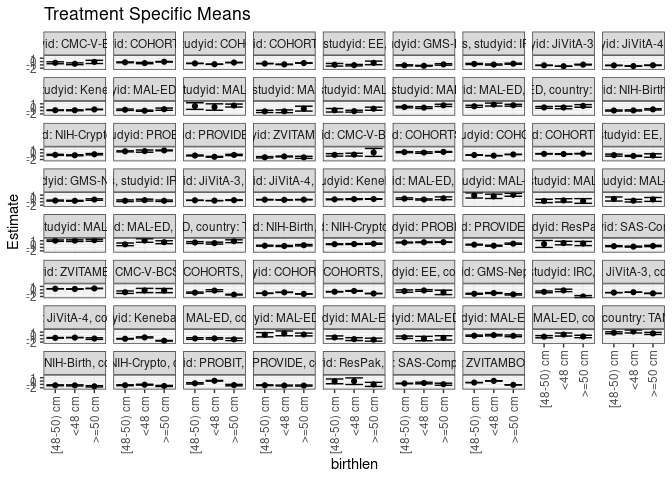

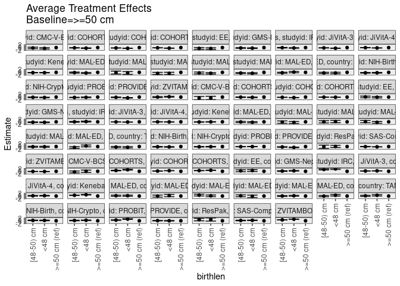

[figure not shown]

## Results Table

### Parameter: TSM

| agecat | studyid | country | intervention_level | baseline_level | estimate | ci_lower | ci_upper |
| --- | --- | --- | --- | --- | --- | --- | --- |
| Birth | CMC-V-BCS-2002 | INDIA | >=50 cm | NA | -0.2463892 | -0.8634083 | 0.3706300 |
| Birth | CMC-V-BCS-2002 | INDIA | <48 cm | NA | -0.2141882 | -0.8419045 | 0.4135282 |
| Birth | CMC-V-BCS-2002 | INDIA | [48-50) cm | NA | -0.7260506 | -1.0900223 | -0.3620790 |
| Birth | COHORTS | GUATEMALA | >=50 cm | NA | -1.4514965 | -1.5761671 | -1.3268259 |
| Birth | COHORTS | GUATEMALA | <48 cm | NA | -0.2433826 | -0.5144826 | 0.0277173 |
| Birth | COHORTS | GUATEMALA | [48-50) cm | NA | -0.8605216 | -1.0394628 | -0.6815805 |
| Birth | COHORTS | INDIA | >=50 cm | NA | -1.2356419 | -1.2949246 | -1.1763592 |
| Birth | COHORTS | INDIA | <48 cm | NA | -0.7707746 | -0.8212599 | -0.7202893 |
| Birth | COHORTS | INDIA | [48-50) cm | NA | -1.0463220 | -1.0927168 | -0.9999271 |
| Birth | COHORTS | PHILIPPINES | >=50 cm | NA | -1.1224220 | -1.1929453 | -1.0518987 |
| Birth | COHORTS | PHILIPPINES | <48 cm | NA | -0.3526877 | -0.4570125 | -0.2483629 |
| Birth | COHORTS | PHILIPPINES | [48-50) cm | NA | -0.5866948 | -0.6554602 | -0.5179294 |
| Birth | EE | PAKISTAN | >=50 cm | NA | -0.7851852 | -1.4439694 | -0.1264010 |
| Birth | EE | PAKISTAN | <48 cm | NA | -0.2040576 | -0.4471992 | 0.0390839 |
| Birth | EE | PAKISTAN | [48-50) cm | NA | -0.3966958 | -0.7425579 | -0.0508338 |
| Birth | GMS-Nepal | NEPAL | >=50 cm | NA | -1.3666771 | -1.5605685 | -1.1727858 |
| Birth | GMS-Nepal | NEPAL | <48 cm | NA | -0.9794651 | -1.1113513 | -0.8475789 |
| Birth | GMS-Nepal | NEPAL | [48-50) cm | NA | -1.1902730 | -1.3300797 | -1.0504664 |
| Birth | IRC | INDIA | >=50 cm | NA | -2.0223400 | -2.3127415 | -1.7319386 |
| Birth | IRC | INDIA | <48 cm | NA | -0.1874233 | -0.5576705 | 0.1828239 |
| Birth | IRC | INDIA | [48-50) cm | NA | -0.6215175 | -0.8751714 | -0.3678636 |
| Birth | JiVitA-3 | BANGLADESH | >=50 cm | NA | -1.0714463 | -1.1305009 | -1.0123916 |
| Birth | JiVitA-3 | BANGLADESH | <48 cm | NA | -0.7236687 | -0.7461411 | -0.7011963 |
| Birth | JiVitA-3 | BANGLADESH | [48-50) cm | NA | -0.8454946 | -0.8783552 | -0.8126341 |
| Birth | JiVitA-4 | BANGLADESH | >=50 cm | NA | -0.9377642 | -1.1755888 | -0.6999397 |
| Birth | JiVitA-4 | BANGLADESH | <48 cm | NA | -0.6422840 | -0.7077848 | -0.5767831 |
| Birth | JiVitA-4 | BANGLADESH | [48-50) cm | NA | -0.7303622 | -0.8264587 | -0.6342658 |
| Birth | Keneba | GAMBIA | >=50 cm | NA | -1.5932106 | -1.6754645 | -1.5109568 |
| Birth | Keneba | GAMBIA | <48 cm | NA | -0.5862396 | -0.7471311 | -0.4253481 |
| Birth | Keneba | GAMBIA | [48-50) cm | NA | -1.0080817 | -1.1076233 | -0.9085401 |

[output cut: 180 more lines]

### Parameter: E(Y)

| agecat | studyid | country | intervention_level | baseline_level | estimate | ci_lower | ci_upper |
| --- | --- | --- | --- | --- | --- | --- | --- |
| Birth | CMC-V-BCS-2002 | INDIA | NA | NA | -0.4648256 | -0.7643210 | -0.1653302 |
| Birth | COHORTS | GUATEMALA | NA | NA | -1.0621429 | -1.1631387 | -0.9611471 |
| Birth | COHORTS | INDIA | NA | NA | -0.9847457 | -1.0145305 | -0.9549609 |
| Birth | COHORTS | PHILIPPINES | NA | NA | -0.7427251 | -0.7890855 | -0.6963647 |
| Birth | EE | PAKISTAN | NA | NA | -0.3333051 | -0.5209779 | -0.1456323 |
| Birth | GMS-Nepal | NEPAL | NA | NA | -1.1164431 | -1.2040134 | -1.0288728 |
| Birth | IRC | INDIA | NA | NA | -1.0105831 | -1.1973019 | -0.8238643 |
| Birth | JiVitA-3 | BANGLADESH | NA | NA | -0.7778272 | -0.7968313 | -0.7588232 |
| Birth | JiVitA-4 | BANGLADESH | NA | NA | -0.6886269 | -0.7410452 | -0.6362086 |
| Birth | Keneba | GAMBIA | NA | NA | -1.2343618 | -1.2966897 | -1.1720339 |
| Birth | MAL-ED | BANGLADESH | NA | NA | -0.9418605 | -1.0869834 | -0.7967375 |
| Birth | MAL-ED | BRAZIL | NA | NA | 0.4029032 | 0.0896793 | 0.7161272 |
| Birth | MAL-ED | INDIA | NA | NA | -0.9324444 | -1.2067907 | -0.6580982 |
| Birth | MAL-ED | NEPAL | NA | NA | -0.7684615 | -1.1257770 | -0.4111460 |
| Birth | MAL-ED | PERU | NA | NA | -0.0520175 | -0.1725298 | 0.0684947 |
| Birth | MAL-ED | SOUTH AFRICA | NA | NA | -0.1925833 | -0.4053570 | 0.0201904 |
| Birth | MAL-ED | TANZANIA, UNITED REPUBLIC OF | NA | NA | 0.7624348 | 0.5710709 | 0.9537986 |
| Birth | NIH-Birth | BANGLADESH | NA | NA | -1.3499217 | -1.4444634 | -1.2553801 |
| Birth | NIH-Crypto | BANGLADESH | NA | NA | -1.2441513 | -1.3281130 | -1.1601897 |
| Birth | PROBIT | BELARUS | NA | NA | -1.1491782 | -1.3593933 | -0.9389630 |
| Birth | PROVIDE | BANGLADESH | NA | NA | -1.2984586 | -1.3752758 | -1.2216415 |
| Birth | ResPak | PAKISTAN | NA | NA | -0.3663158 | -0.7677415 | 0.0351099 |
| Birth | SAS-CompFeed | INDIA | NA | NA | -0.6700453 | -0.8474950 | -0.4925957 |
| Birth | ZVITAMBO | ZIMBABWE | NA | NA | -0.5154897 | -0.5413479 | -0.4896314 |
| 6 months | CMC-V-BCS-2002 | INDIA | NA | NA | -0.4931429 | -0.7890257 | -0.1972601 |
| 6 months | COHORTS | GUATEMALA | NA | NA | 0.2193904 | 0.1338361 | 0.3049448 |
| 6 months | COHORTS | INDIA | NA | NA | -0.6983940 | -0.7275858 | -0.6692022 |
| 6 months | COHORTS | PHILIPPINES | NA | NA | -0.2943461 | -0.3357404 | -0.2529517 |
| 6 months | EE | PAKISTAN | NA | NA | -0.8527871 | -0.9897809 | -0.7157933 |
| 6 months | GMS-Nepal | NEPAL | NA | NA | -0.6026850 | -0.6889114 | -0.5164586 |
| 6 months | IRC | INDIA | NA | NA | -0.6409340 | -0.7788045 | -0.5030635 |
| 6 months | JiVitA-3 | BANGLADESH | NA | NA | -0.6072473 | -0.6281750 | -0.5863195 |
| 6 months | JiVitA-4 | BANGLADESH | NA | NA | -0.3757033 | -0.4185197 | -0.3328869 |
| 6 months | Keneba | GAMBIA | NA | NA | -0.1974657 | -0.2592285 | -0.1357029 |
| 6 months | MAL-ED | BANGLADESH | NA | NA | -0.1458294 | -0.2842227 | -0.0074361 |
| 6 months | MAL-ED | BRAZIL | NA | NA | 0.8580508 | 0.5394364 | 1.1766653 |
| 6 months | MAL-ED | INDIA | NA | NA | -0.6644715 | -0.9812646 | -0.3476785 |
| 6 months | MAL-ED | NEPAL | NA | NA | -0.4072436 | -0.7125541 | -0.1019331 |
| 6 months | MAL-ED | PERU | NA | NA | 1.0510698 | 0.9102569 | 1.1918826 |
| 6 months | MAL-ED | SOUTH AFRICA | NA | NA | 0.4017921 | 0.1396820 | 0.6639023 |
| 6 months | MAL-ED | TANZANIA, UNITED REPUBLIC OF | NA | NA | 0.5110593 | 0.3321196 | 0.6899991 |
| 6 months | NIH-Birth | BANGLADESH | NA | NA | -0.4636760 | -0.5549942 | -0.3723578 |
| 6 months | NIH-Crypto | BANGLADESH | NA | NA | 0.0297622 | -0.0491685 | 0.1086930 |
| 6 months | PROBIT | BELARUS | NA | NA | 0.5741099 | 0.5141290 | 0.6340908 |
| 6 months | PROVIDE | BANGLADESH | NA | NA | -0.1990907 | -0.2817968 | -0.1163845 |
| 6 months | ResPak | PAKISTAN | NA | NA | 0.2176471 | -0.1948962 | 0.6301903 |
| 6 months | SAS-CompFeed | INDIA | NA | NA | -0.6674924 | -0.8047012 | -0.5302836 |
| 6 months | ZVITAMBO | ZIMBABWE | NA | NA | 0.3089671 | 0.2831612 | 0.3347730 |
| 24 months | CMC-V-BCS-2002 | INDIA | NA | NA | -0.4529088 | -0.6339053 | -0.2719123 |
| 24 months | COHORTS | GUATEMALA | NA | NA | -0.2016312 | -0.2740358 | -0.1292266 |
| 24 months | COHORTS | INDIA | NA | NA | -0.5945743 | -0.6244188 | -0.5647299 |
| 24 months | COHORTS | PHILIPPINES | NA | NA | -0.6103189 | -0.6471371 | -0.5735006 |
| 24 months | EE | PAKISTAN | NA | NA | -0.9929439 | -1.1707082 | -0.8151796 |
| 24 months | GMS-Nepal | NEPAL | NA | NA | -1.1336900 | -1.2226955 | -1.0446844 |
| 24 months | IRC | INDIA | NA | NA | -0.7536624 | -0.8467166 | -0.6606082 |
| 24 months | JiVitA-3 | BANGLADESH | NA | NA | -1.3046571 | -1.3299587 | -1.2793555 |
| 24 months | JiVitA-4 | BANGLADESH | NA | NA | -1.2411122 | -1.2752162 | -1.2070083 |
| 24 months | Keneba | GAMBIA | NA | NA | -0.7949018 | -0.8551887 | -0.7346150 |
| 24 months | MAL-ED | BANGLADESH | NA | NA | -0.8296257 | -0.9583167 | -0.7009347 |
| 24 months | MAL-ED | BRAZIL | NA | NA | 0.2347222 | -0.1702799 | 0.6397243 |
| 24 months | MAL-ED | INDIA | NA | NA | -1.1144872 | -1.3842438 | -0.8447305 |
| 24 months | MAL-ED | NEPAL | NA | NA | -0.8921154 | -1.1547051 | -0.6295257 |
| 24 months | MAL-ED | PERU | NA | NA | 0.0490417 | -0.0909855 | 0.1890689 |
| 24 months | MAL-ED | SOUTH AFRICA | NA | NA | 0.3919414 | 0.2031981 | 0.5806847 |
| 24 months | MAL-ED | TANZANIA, UNITED REPUBLIC OF | NA | NA | 0.1324519 | -0.0568428 | 0.3217466 |
| 24 months | NIH-Birth | BANGLADESH | NA | NA | -0.9069451 | -1.0069853 | -0.8069049 |
| 24 months | NIH-Crypto | BANGLADESH | NA | NA | -0.6103502 | -0.7050157 | -0.5156847 |
| 24 months | PROBIT | BELARUS | NA | NA | 0.6981406 | 0.5843775 | 0.8119038 |
| 24 months | PROVIDE | BANGLADESH | NA | NA | -0.8928670 | -0.9755153 | -0.8102187 |
| 24 months | ZVITAMBO | ZIMBABWE | NA | NA | -1.1803052 | -1.2806626 | -1.0799477 |

### Parameter: ATE

| agecat | studyid | country | intervention_level | baseline_level | estimate | ci_lower | ci_upper |
| --- | --- | --- | --- | --- | --- | --- | --- |
| Birth | CMC-V-BCS-2002 | INDIA | >=50 cm | >=50 cm | 0.0000000 | 0.0000000 | 0.0000000 |
| Birth | CMC-V-BCS-2002 | INDIA | <48 cm | >=50 cm | 0.0322010 | -0.8509038 | 0.9153058 |
| Birth | CMC-V-BCS-2002 | INDIA | [48-50) cm | >=50 cm | -0.4796615 | -1.1994631 | 0.2401402 |
| Birth | COHORTS | GUATEMALA | >=50 cm | >=50 cm | 0.0000000 | 0.0000000 | 0.0000000 |
| Birth | COHORTS | GUATEMALA | <48 cm | >=50 cm | 1.2081139 | 0.9100837 | 1.5061440 |
| Birth | COHORTS | GUATEMALA | [48-50) cm | >=50 cm | 0.5909749 | 0.3730283 | 0.8089214 |
| Birth | COHORTS | INDIA | >=50 cm | >=50 cm | 0.0000000 | 0.0000000 | 0.0000000 |
| Birth | COHORTS | INDIA | <48 cm | >=50 cm | 0.4648673 | 0.3871559 | 0.5425786 |
| Birth | COHORTS | INDIA | [48-50) cm | >=50 cm | 0.1893199 | 0.1141701 | 0.2644698 |
| Birth | COHORTS | PHILIPPINES | >=50 cm | >=50 cm | 0.0000000 | 0.0000000 | 0.0000000 |
| Birth | COHORTS | PHILIPPINES | <48 cm | >=50 cm | 0.7697344 | 0.6445040 | 0.8949647 |
| Birth | COHORTS | PHILIPPINES | [48-50) cm | >=50 cm | 0.5357273 | 0.4378269 | 0.6336276 |
| Birth | EE | PAKISTAN | >=50 cm | >=50 cm | 0.0000000 | 0.0000000 | 0.0000000 |
| Birth | EE | PAKISTAN | <48 cm | >=50 cm | 0.5811276 | -0.1213144 | 1.2835695 |
| Birth | EE | PAKISTAN | [48-50) cm | >=50 cm | 0.3884894 | -0.3553178 | 1.1322965 |
| Birth | GMS-Nepal | NEPAL | >=50 cm | >=50 cm | 0.0000000 | 0.0000000 | 0.0000000 |
| Birth | GMS-Nepal | NEPAL | <48 cm | >=50 cm | 0.3872121 | 0.1531490 | 0.6212751 |
| Birth | GMS-Nepal | NEPAL | [48-50) cm | >=50 cm | 0.1764041 | -0.0616296 | 0.4144378 |
| Birth | IRC | INDIA | >=50 cm | >=50 cm | 0.0000000 | 0.0000000 | 0.0000000 |
| Birth | IRC | INDIA | <48 cm | >=50 cm | 1.8349167 | 1.3636875 | 2.3061459 |
| Birth | IRC | INDIA | [48-50) cm | >=50 cm | 1.4008226 | 1.0135044 | 1.7881407 |
| Birth | JiVitA-3 | BANGLADESH | >=50 cm | >=50 cm | 0.0000000 | 0.0000000 | 0.0000000 |
| Birth | JiVitA-3 | BANGLADESH | <48 cm | >=50 cm | 0.3477776 | 0.2860117 | 0.4095435 |
| Birth | JiVitA-3 | BANGLADESH | [48-50) cm | >=50 cm | 0.2259516 | 0.1601376 | 0.2917657 |
| Birth | JiVitA-4 | BANGLADESH | >=50 cm | >=50 cm | 0.0000000 | 0.0000000 | 0.0000000 |
| Birth | JiVitA-4 | BANGLADESH | <48 cm | >=50 cm | 0.2954802 | 0.0482878 | 0.5426727 |
| Birth | JiVitA-4 | BANGLADESH | [48-50) cm | >=50 cm | 0.2074020 | -0.0490659 | 0.4638699 |
| Birth | Keneba | GAMBIA | >=50 cm | >=50 cm | 0.0000000 | 0.0000000 | 0.0000000 |
| Birth | Keneba | GAMBIA | <48 cm | >=50 cm | 1.0069710 | 0.8264829 | 1.1874592 |
| Birth | Keneba | GAMBIA | [48-50) cm | >=50 cm | 0.5851289 | 0.4563909 | 0.7138670 |

[output cut: 180 more lines]

### Parameter: PAR

| agecat | studyid | country | intervention_level | baseline_level | estimate | ci_lower | ci_upper |
| --- | --- | --- | --- | --- | --- | --- | --- |
| Birth | CMC-V-BCS-2002 | INDIA | >=50 cm | NA | -0.2184364 | -0.8301930 | 0.3933202 |
| Birth | COHORTS | GUATEMALA | >=50 cm | NA | 0.3893536 | 0.2932714 | 0.4854359 |
| Birth | COHORTS | INDIA | >=50 cm | NA | 0.2508962 | 0.1974027 | 0.3043898 |
| Birth | COHORTS | PHILIPPINES | >=50 cm | NA | 0.3796970 | 0.3225355 | 0.4368584 |
| Birth | EE | PAKISTAN | >=50 cm | NA | 0.4518801 | -0.1669431 | 1.0707033 |
| Birth | GMS-Nepal | NEPAL | >=50 cm | NA | 0.2502341 | 0.0717847 | 0.4286835 |
| Birth | IRC | INDIA | >=50 cm | NA | 1.0117569 | 0.7634903 | 1.2600236 |
| Birth | JiVitA-3 | BANGLADESH | >=50 cm | NA | 0.2936190 | 0.2373010 | 0.3499370 |
| Birth | JiVitA-4 | BANGLADESH | >=50 cm | NA | 0.2491373 | 0.0225558 | 0.4757188 |
| Birth | Keneba | GAMBIA | >=50 cm | NA | 0.3588489 | 0.2972560 | 0.4204417 |
| Birth | MAL-ED | BANGLADESH | >=50 cm | NA | 0.2275788 | -0.1037777 | 0.5589352 |
| Birth | MAL-ED | BRAZIL | >=50 cm | NA | 0.1324530 | -0.2079015 | 0.4728074 |
| Birth | MAL-ED | INDIA | >=50 cm | NA | 0.3431111 | -0.0993435 | 0.7855657 |
| Birth | MAL-ED | NEPAL | >=50 cm | NA | -0.0397115 | -0.5703614 | 0.4909384 |
| Birth | MAL-ED | PERU | >=50 cm | NA | 0.0751309 | -0.1531449 | 0.3034066 |
| Birth | MAL-ED | SOUTH AFRICA | >=50 cm | NA | 0.1312317 | -0.1624357 | 0.4248991 |
| Birth | MAL-ED | TANZANIA, UNITED REPUBLIC OF | >=50 cm | NA | 0.1596795 | -0.1268344 | 0.4461934 |
| Birth | NIH-Birth | BANGLADESH | >=50 cm | NA | 0.2243716 | 0.0591922 | 0.3895511 |
| Birth | NIH-Crypto | BANGLADESH | >=50 cm | NA | 0.2254295 | 0.0808441 | 0.3700148 |
| Birth | PROBIT | BELARUS | >=50 cm | NA | 0.0544419 | 0.0296588 | 0.0792250 |
| Birth | PROVIDE | BANGLADESH | >=50 cm | NA | 0.0480488 | -0.0920985 | 0.1881962 |
| Birth | ResPak | PAKISTAN | >=50 cm | NA | 0.6267533 | 0.0935513 | 1.1599554 |
| Birth | SAS-CompFeed | INDIA | >=50 cm | NA | 0.2744625 | 0.1120072 | 0.4369178 |
| Birth | ZVITAMBO | ZIMBABWE | >=50 cm | NA | 0.6158158 | 0.5782509 | 0.6533807 |
| 6 months | CMC-V-BCS-2002 | INDIA | >=50 cm | NA | -0.6245656 | -1.6727050 | 0.4235737 |
| 6 months | COHORTS | GUATEMALA | >=50 cm | NA | -0.0586755 | -0.1432167 | 0.0258656 |
| 6 months | COHORTS | INDIA | >=50 cm | NA | -0.2205802 | -0.2738466 | -0.1673138 |
| 6 months | COHORTS | PHILIPPINES | >=50 cm | NA | -0.0433452 | -0.0975761 | 0.0108858 |
| 6 months | EE | PAKISTAN | >=50 cm | NA | -0.0422247 | -0.5289072 | 0.4444577 |
| 6 months | GMS-Nepal | NEPAL | >=50 cm | NA | -0.2811037 | -0.4817074 | -0.0805001 |
| 6 months | IRC | INDIA | >=50 cm | NA | 0.0435173 | -0.1386911 | 0.2257257 |
| 6 months | JiVitA-3 | BANGLADESH | >=50 cm | NA | -0.1119313 | -0.1892668 | -0.0345957 |
| 6 months | JiVitA-4 | BANGLADESH | >=50 cm | NA | -0.0329278 | -0.0999796 | 0.0341240 |
| 6 months | Keneba | GAMBIA | >=50 cm | NA | -0.0412023 | -0.1033192 | 0.0209146 |
| 6 months | MAL-ED | BANGLADESH | >=50 cm | NA | -0.1960204 | -0.5538457 | 0.1618050 |
| 6 months | MAL-ED | BRAZIL | >=50 cm | NA | -0.2354285 | -0.6050186 | 0.1341616 |
| 6 months | MAL-ED | INDIA | >=50 cm | NA | 0.0857368 | -0.5470478 | 0.7185213 |
| 6 months | MAL-ED | NEPAL | >=50 cm | NA | -0.1191186 | -0.5907705 | 0.3525333 |
| 6 months | MAL-ED | PERU | >=50 cm | NA | -0.1180725 | -0.3811248 | 0.1449798 |
| 6 months | MAL-ED | SOUTH AFRICA | >=50 cm | NA | -0.1724993 | -0.5330849 | 0.1880863 |
| 6 months | MAL-ED | TANZANIA, UNITED REPUBLIC OF | >=50 cm | NA | -0.3567759 | -0.7043084 | -0.0092435 |
| 6 months | NIH-Birth | BANGLADESH | >=50 cm | NA | -0.1446435 | -0.3163828 | 0.0270958 |
| 6 months | NIH-Crypto | BANGLADESH | >=50 cm | NA | -0.0886311 | -0.2318093 | 0.0545471 |
| 6 months | PROBIT | BELARUS | >=50 cm | NA | -0.0086752 | -0.0177448 | 0.0003944 |
| 6 months | PROVIDE | BANGLADESH | >=50 cm | NA | -0.3352528 | -0.4900681 | -0.1804376 |
| 6 months | ResPak | PAKISTAN | >=50 cm | NA | 0.0330701 | -0.5608399 | 0.6269802 |
| 6 months | SAS-CompFeed | INDIA | >=50 cm | NA | -0.1278319 | -0.2235222 | -0.0321417 |
| 6 months | ZVITAMBO | ZIMBABWE | >=50 cm | NA | -0.0870441 | -0.1276313 | -0.0464568 |
| 24 months | CMC-V-BCS-2002 | INDIA | >=50 cm | NA | -0.3467910 | -0.7960854 | 0.1025035 |
| 24 months | COHORTS | GUATEMALA | >=50 cm | NA | -0.1402617 | -0.2177114 | -0.0628120 |
| 24 months | COHORTS | INDIA | >=50 cm | NA | -0.2976860 | -0.3524503 | -0.2429217 |
| 24 months | COHORTS | PHILIPPINES | >=50 cm | NA | -0.1605295 | -0.2077826 | -0.1132764 |
| 24 months | EE | PAKISTAN | >=50 cm | NA | -0.5956418 | -1.1190889 | -0.0721947 |
| 24 months | GMS-Nepal | NEPAL | >=50 cm | NA | -0.2793427 | -0.4835985 | -0.0750868 |
| 24 months | IRC | INDIA | >=50 cm | NA | -0.1164464 | -0.2434961 | 0.0106032 |
| 24 months | JiVitA-3 | BANGLADESH | >=50 cm | NA | -0.3782753 | -0.4966063 | -0.2599442 |
| 24 months | JiVitA-4 | BANGLADESH | >=50 cm | NA | -0.1343063 | -0.1934857 | -0.0751270 |
| 24 months | Keneba | GAMBIA | >=50 cm | NA | -0.1223611 | -0.1829261 | -0.0617960 |
| 24 months | MAL-ED | BANGLADESH | >=50 cm | NA | -0.2366874 | -0.5187537 | 0.0453789 |
| 24 months | MAL-ED | BRAZIL | >=50 cm | NA | -0.2581359 | -0.6980043 | 0.1817325 |
| 24 months | MAL-ED | INDIA | >=50 cm | NA | -0.6786538 | -1.3465606 | -0.0107471 |
| 24 months | MAL-ED | NEPAL | >=50 cm | NA | -0.4314904 | -0.8201628 | -0.0428180 |
| 24 months | MAL-ED | PERU | >=50 cm | NA | -0.5064653 | -0.8192885 | -0.1936421 |
| 24 months | MAL-ED | SOUTH AFRICA | >=50 cm | NA | -0.1886870 | -0.4385830 | 0.0612089 |
| 24 months | MAL-ED | TANZANIA, UNITED REPUBLIC OF | >=50 cm | NA | -0.2507710 | -0.5956068 | 0.0940648 |
| 24 months | NIH-Birth | BANGLADESH | >=50 cm | NA | -0.2589871 | -0.4231690 | -0.0948053 |
| 24 months | NIH-Crypto | BANGLADESH | >=50 cm | NA | -0.1931943 | -0.3574047 | -0.0289840 |
| 24 months | PROBIT | BELARUS | >=50 cm | NA | -0.0237698 | -0.0428859 | -0.0046536 |
| 24 months | PROVIDE | BANGLADESH | >=50 cm | NA | -0.2645309 | -0.4251596 | -0.1039021 |
| 24 months | ZVITAMBO | ZIMBABWE | >=50 cm | NA | 0.1675972 | -0.1292208 | 0.4644153 |